# Lab 2: Mine Crafting

## Part 4: An infintely deep mine

### Question 4.1

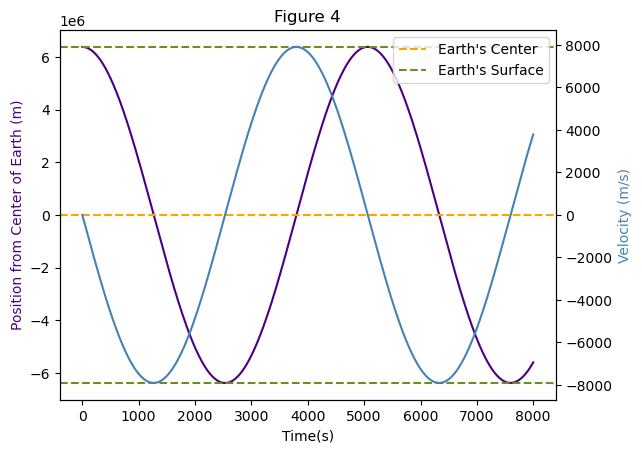

```python
a=0
def g(y):
    gr=g0*y/Re
    return gr

def Q4(t,l):
    y,v=l
    dydt=v
    dvdt=-g(y)+a*v**m
    return[dydt,dvdt]

t0,tf=0,8000
t_eval=np.linspace(t0,tf,10000)

y0=Re #m
v0=0 #m/s
ic=[y0,v0]

def eventstop(t,l):
    y,v=l
    return y+Re

eventstop.terminal=True

sol5=solve_ivp(fun=Q4,t_span=(t0,tf),y0=ic,t_eval=t_eval,events=eventstop)

y5=sol5.y[0]
v5=sol5.y[1]
t_vals=sol5.t

fig,ax5=plt.subplots()
ax5.plot(t_vals,y5,color='indigo')
ax5.axhline(y=0,color='orange',label="Earth's Center",ls='--')
ax5.axhline(y=Re,color='olivedrab',label="Earth's Surface",ls='--')
ax5.axhline(y=-Re,color='olivedrab',ls='--')
ax5.set_ylabel('Position from Center of Earth (m)',color='indigo')
ax5.set_ylim(-1.1*Re,1.1*Re)

ax52=ax5.twinx()
ax52.plot(t_vals,v5,label='Velocity',color='steelblue')
ax52.set_ylabel('Velocity (m/s)',color='steelblue')

ax5.set_xlabel('Time(s)')
ax5.set_title('Figure 4')

ax5.legend()
```

Figure 4: This graph represents the object's position and velocity oscillating in a sinusoidal wave, traveling back and forth between opposing edges of the Earth's surface. This is a theoretical infinite mine from pole to pole, therefore, the Coriolis force is negligible.

### Question 4.2

##### How long it will take to reach the other side:

```python
def eventstop(t,l):
    y,v=l
    return v
eventstop.terminal=False
sol5=solve_ivp(fun=Q4,t_span=(t0,tf),y0=ic,t_eval=t_eval,events=eventstop)

t_otherside=sol5.t_events[0][1]
print(f'The object will reach the other side of the Earth after {t_otherside} seconds.')
```

```
The object will reach the other side of the Earth after 2532.6120147256643 seconds.
```

##### Time the object reaches the center of the Earth:

```python
y_stop=0
def eventstop(t,l):
    y,v=l
    return y
eventstop.terminal=True
sol5=solve_ivp(fun=Q4,t_span=(t0,tf),y0=ic,t_eval=t_eval,events=eventstop)

t_center_earth_t=sol5.t_events[0][0]
t_center_v=sol5.y_events[0][0][1]
post_center_v=np.abs(t_center_v)

print(f'The object will reach the center of the Earth at {t_center_earth_t} seconds and with a speed of {post_center_v} m/s downwards.')
```

```
The object will reach the center of the Earth at 1266.473469558803 seconds and with a speed of 7910.759872777071 m/s downwards.
```

### Question 4.3

##### Orbital Speed and Period:

```python
orbit_v=np.sqrt(G*Me/Re)
print(f'Orbital Speed = {orbit_v} m/s')
orbit_p=np.pi*2*Re/orbit_v
print(f'Orbital Period = {orbit_p} seconds')
```

```
Orbital Speed = 7905.277129890415 m/s
Orbital Period = 5069.371199675785 seconds
```

##### Comparison

The crossing time at the center of Earth is almost exactly a quarter of the orbital period.

```python
print(f'The crossing time at the center of Earth is almost exactly a quarter of the orbital period. 4*CrossTime={4*t_center_earth_t}, and the orbital period = {orbit_p}.')
```

```
The crossing time at the center of Earth is almost exactly a quarter of the orbital period. 4*CrossTime=5065.893878235212, and the orbital period = 5069.371199675785.
```

## Part 5: A non-uniform Earth

### Question 5.1

##### Normalized Density Profile and Figure 5

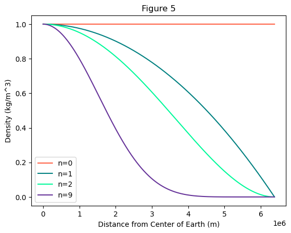

```python
pn=1
def p_0(y):
    n=0
    pr=(1-y**2/Re**2)**n
    return pr
def p_1(y):
    n=1
    pr=pn*(1-y**2/Re**2)**n
    return pr
def p_2(y):
    n=2
    pr=pn*(1-y**2/Re**2)**n
    return pr
def p_9(y):
    n=9
    pr=pn*(1-y**2/Re**2)**n
    return pr

fig,ax6=plt.subplots()
y_data=np.linspace(0,Re,10000)
p_0_data=p_0(y_data)
p_1_data=p_1(y_data)
p_2_data=p_2(y_data)
p_9_data=p_9(y_data)
ax6.plot(y_data,p_0_data,label='n=0',color='tomato')
ax6.plot(y_data,p_1_data,label='n=1',color='teal')
ax6.plot(y_data,p_2_data,label='n=2',color='mediumspringgreen')
ax6.plot(y_data,p_9_data,label='n=9',color='rebeccapurple')

ax6.set_title('Figure 5')
ax6.set_xlabel('Distance from Center of Earth (m)')
ax6.set_ylabel('Density (kg/m^3)')
ax6.legend()
```

### Question 5.2

##### Solving for Pn

$ M_e=4π\int_0^{R_e}p(r)r^2dr\ $

$ p(r)=p_n(1-r^2/R_e^2)^n $

$ p_n=M_e/(4π\int_0^{R_e}(1-r^2/R_e^2)r^2dr) $

##### Force Profile and Figure 6

```
5494.8674095512 13737.168523877996 24040.044916786497 135545.12141863423
```

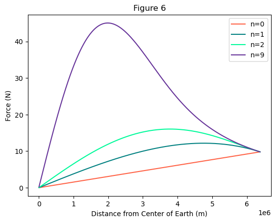

```python
pn0=Me/(4*np.pi*scipy.integrate.quad((lambda y:(p_0(y))*y**2),0,Re)[0])
pn1=Me/(4*np.pi*scipy.integrate.quad((lambda y:(p_1(y))*y**2),0,Re)[0])
pn2=Me/(4*np.pi*scipy.integrate.quad((lambda y:(p_2(y))*y**2),0,Re)[0])
pn9=Me/(4*np.pi*scipy.integrate.quad((lambda y:(p_9(y))*y**2),0,Re)[0])
print(pn0,pn1,pn2,pn9)
def F0(y):
    M=4*np.pi*pn0*scipy.integrate.quad((lambda y:(p_0(y))*y**2),0,y)[0]
    F=G*M/y**2
    return F

def F1(y):
    M=4*np.pi*pn1*scipy.integrate.quad((lambda y:(p_1(y))*y**2),0,y)[0]
    F=G*M/y**2
    return F
def F2(y):
    M=4*np.pi*pn2*scipy.integrate.quad((lambda y:(p_2(y))*y**2),0,y)[0]
    F=G*M/y**2
    return F
def F9(y):
    M=4*np.pi*pn9*scipy.integrate.quad((lambda y:(p_9(y))*y**2),0,y)[0]
    F=G*M/y**2
    return F
y_data=np.linspace(0,Re,1000)
F0_data=[F0(y) for y in y_data]
F1_data=[F1(y) for y in y_data]
F2_data=[F2(y) for y in y_data]
F9_data=[F9(y) for y in y_data]

fig,ax7=plt.subplots()
ax7.plot(y_data,F0_data,label='n=0',color='tomato')
ax7.plot(y_data,F1_data,label='n=1',color='teal')
ax7.plot(y_data,F2_data,label='n=2',color='mediumspringgreen')
ax7.plot(y_data,F9_data,label='n=9',color='rebeccapurple')

ax7.set_title('Figure 6')
ax7.set_xlabel('Distance from Center of Earth (m)')
ax7.set_ylabel('Force (N)')
ax7.legend()
```

Figure 6: This graph represents the difference in force with respect to the distance from the center of the Earth, with n values 0, 1, 2, and 9 that represent different density distributions of Earth.

### Question 5.3:

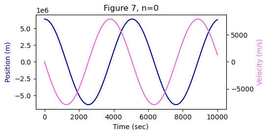

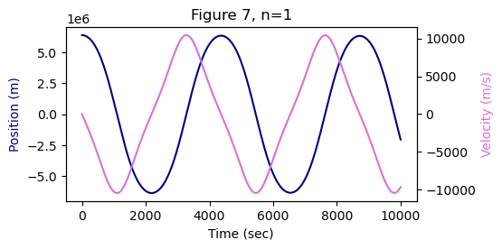

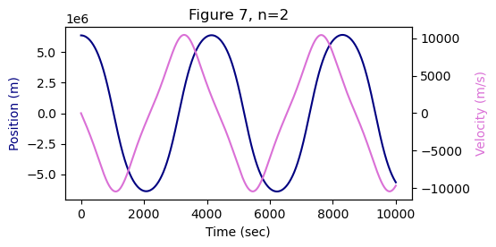

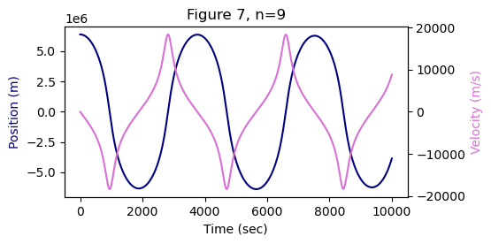

```python
a=0
m=2
y0=Re #m
v0=0 #m/s
ic=[y0,v0]
t0,tf=0,10000
t_eval=np.linspace(t0,tf,100000)


def Q50(t,l):
    y,v=l
    dydt=v
    dvdt=-F0(y)-a*v**m
    return[dydt,dvdt]

sol6=solve_ivp(fun=Q50,t_span=(t0,tf),y0=ic,t_eval=t_eval)
pos0=sol6.y[0]
vel0=sol6.y[1]
t_vals0=sol6.t

fig,ax60=plt.subplots(figsize=(5,2.5))
ax60.plot(t_vals0,pos0,label='Position',color='navy')
ax70=ax60.twinx()
ax70.plot(t_vals0,vel0,label='Velocity',color='orchid')
ax70.set_title('Figure 7, n=0')
ax60.set_xlabel('Time (sec)')
ax60.set_ylabel('Position (m)',color='navy')
ax70.set_ylabel('Velocity (m/s)',color='orchid')


def Q51(t,l):
    y,v=l
    dydt=v
    dvdt=-F1(y)-a*v**m
    return[dydt,dvdt]

sol6=solve_ivp(fun=Q51,t_span=(t0,tf),y0=ic,t_eval=t_eval)
pos1=sol6.y[0]
vel1=sol6.y[1]
t_vals1=sol6.t

fig,ax61=plt.subplots(figsize=(5,2.5))
ax61.plot(t_vals1,pos1,label='Position',color='navy')
ax71=ax61.twinx()
ax71.plot(t_vals1,vel1,label='Velocity',color='orchid')
ax71.set_title('Figure 7, n=1')
ax61.set_xlabel('Time (sec)')
ax61.set_ylabel('Position (m)',color='navy')
ax71.set_ylabel('Velocity (m/s)',color='orchid')


def Q52(t,l):
    y,v=l
    dydt=v
    dvdt=-F2(y)-a*v**m
    return[dydt,dvdt]

sol6=solve_ivp(fun=Q52,t_span=(t0,tf),y0=ic,t_eval=t_eval)
pos2=sol6.y[0]
vel2=sol6.y[1]
t_vals2=sol6.t

fig,ax62=plt.subplots(figsize=(5,2.5))
ax62.plot(t_vals2,pos2,label='Position',color='navy')
ax72=ax62.twinx()
ax72.plot(t_vals1,vel1,label='Velocity',color='orchid')
ax72.set_title('Figure 7, n=2')
ax62.set_xlabel('Time (sec)')
ax62.set_ylabel('Position (m)',color='navy')
ax72.set_ylabel('Velocity (m/s)',color='orchid')


def Q59(t,l):
    y,v=l
    dydt=v
    dvdt=-F9(y)-a*v**m
    return[dydt,dvdt]

sol6=solve_ivp(fun=Q59,t_span=(t0,tf),y0=ic,t_eval=t_eval)
pos9=sol6.y[0]
vel9=sol6.y[1]
t_vals9=sol6.t

fig,ax69=plt.subplots(figsize=(5,2.5))
ax69.plot(t_vals9,pos9,label='Position',color='navy')
ax79=ax69.twinx()
ax79.plot(t_vals9,vel9,label='Velocity',color='orchid')
ax79.set_title('Figure 7, n=9')
ax69.set_xlabel('Time (sec)')
ax69.set_ylabel('Position (m)',color='navy')
ax79.set_ylabel('Velocity (m/s)',color='orchid')
```

Figure 7: These graphs indicate various patterns of position and velocity based on different distributions of density of the Earth.

### Question 5.4

```python
y_stop=0
def eventstop(t,l):
    y,v=l
    return y
eventstop.terminal=True

sol60=solve_ivp(fun=Q50,t_span=(t0,tf),y0=ic,t_eval=t_eval,events=eventstop)
t_center_t0=sol60.t_events[0][0]
t_center_v0=sol60.y_events[0][0][1]
post_center_v0=np.abs(t_center_v0)

sol61=solve_ivp(fun=Q51,t_span=(t0,tf),y0=ic,t_eval=t_eval,events=eventstop)
t_center_t1=sol61.t_events[0][0]
t_center_v1=sol61.y_events[0][0][1]
post_center_v1=np.abs(t_center_v1)

sol62=solve_ivp(fun=Q52,t_span=(t0,tf),y0=ic,t_eval=t_eval,events=eventstop)
t_center_t2=sol62.t_events[0][0]
t_center_v2=sol62.y_events[0][0][1]
post_center_v2=np.abs(t_center_v2)

sol69=solve_ivp(fun=Q59,t_span=(t0,tf),y0=ic,t_eval=t_eval,events=eventstop)
t_center_t9=sol69.t_events[0][0]
t_center_v9=sol69.y_events[0][0][1]
post_center_v9=np.abs(t_center_v9)

print(f'For density n=0, the object will reach the center of the Earth at {t_center_t0} seconds and with a speed of {post_center_v0} m/s downwards. \n\nFor density n=1, the object will reach the center of the Earth at {t_center_t1} seconds and with a speed of {post_center_v1} m/s downwards. \n\nFor density n=2, the object will reach the center of the Earth at {t_center_t2} seconds and with a speed of {post_center_v2} m/s downwards.\n\nFor density n=9, the object will reach the center of the Earth at {t_center_t9} seconds and with a speed of {post_center_v9} m/s downwards. ')
```

```
For density n=0, the object will reach the center of the Earth at 1267.2409534601416 seconds and with a speed of 7905.971248072909 m/s downwards.

For density n=1, the object will reach the center of the Earth at 1096.8914820025398 seconds and with a speed of 10435.238778034942 m/s downwards.

For density n=2, the object will reach the center of the Earth at 1035.13877542547 seconds and with a speed of 12200.745609087611 m/s downwards.

For density n=9, the object will reach the center of the Earth at 943.8748065601559 seconds and with a speed of 18391.99683151908 m/s downwards.
```

## Part 6: A Lunar Mine Shaft

### Question 6.1

```python
gm_surface=G*Mm/Rm**2
def Q6(t,l):
    y,v=l
    dydt=v
    dvdt=-gm_surface*y/Rm
    return[dydt,dvdt]

t0,tf=0,10000
t_eval=np.linspace(t0,tf,100000)

y0=Re #m
v0=0 #m/s
ic=[y0,v0]

y_stop=0
def eventstop(t,l):
    y,v=l
    return y
eventstop.terminal=False

sol7=solve_ivp(fun=Q6,t_span=(t0,tf),y0=ic,t_eval=t_eval,events=eventstop)
t_center_moon_t=sol7.t_events[0][0]
print(f'The object would reach the center of the moon after {t_center_moon_t} seconds.')
```

```
The object would reach the center of the moon after 1625.038707011607 seconds.
```

### Question 6.2

```python
#density=mass/volume
vol_m=4/3*np.pi*Rm**3
vol_e=4/3*np.pi*Re**3
den_m=Mm/vol_m
den_e=Me/vol_e
print(f'The density of the moon is {den_m}kg/m\u00B3, and the density of the Earth is {den_e}kg/m\u00B3. Therefore, the moon is less dense than the Earth.')
```

```
The density of the moon is 3341.753803870318kg/m³, and the density of the Earth is 5494.867409551201kg/m³. Therefore, the moon is less dense than the Earth.
```

### Question 6.3

The fall time and orbit time are related, with the fall time being about a quarter of that of the orbit time, as demonstrated by the orbit time 5069.371199675785 seconds and the fall time of 1266.473469558803 seconds.

$$ T_{\text{orbit}} = 2π\sqrt{\frac{R^3}{GM}} $$

Note that both orbit and fall time are based on mass.

When applied to the orbit time: $$ T_{\text{orbit}} = 2π\sqrt{\frac{R^3}{GM}}= 2π\sqrt{\frac{R^3}{G\cdot\frac{4}{3}πR^3 \rho}} = 2π\sqrt{\frac{1}{\frac{4}{3}π G \rho}} \propto \cdot \frac{1}{\sqrt{\rho}} $$

In a similar manner, the fall time can be written as: $$ T_{\text{fall}} = \propto \cdot \frac{1}{\sqrt{\rho}} $$

Therefore, both orbit and fall time are inversely proportional to the square root of the density of the planet.